# Overview

Dataset info

| Number of variables | 12 |
| --- | --- |
| Number of observations | 1000 |
| Total Missing (%) | 1.6% |
| Total size in memory | 93.8 KiB |
| Average record size in memory | 96.1 B |

Variables types

| Numeric | 7 |
| --- | --- |
| Categorical | 4 |
| Boolean | 0 |
| Date | 0 |
| Text (Unique) | 1 |
| Rejected | 0 |
| Unsupported | 0 |

Warnings

- `Actors` has a high cardinality: 996 distinct values Warning
- `Director` has a high cardinality: 644 distinct values Warning
- `Genre` has a high cardinality: 207 distinct values Warning
- `Metascore` has 64 / 6.4% missing values Missing
- `Revenue (Millions)` has 128 / 12.8% missing values Missing
- `Title` has a high cardinality: 999 distinct values Warning

# Variables

Actors  
Categorical

| Distinct count | 996 |
| --- | --- |
| Unique (%) | 99.6% |
| Missing (%) | 0.0% |
| Missing (n) | 0 |

| Gerard Butler, Aaron Eckhart, Morgan Freeman,Angela Bassett | 2 |
| --- | --- |
| Jennifer Lawrence, Josh Hutcherson, Liam Hemsworth, Woody Harrelson | 2 |
| Daniel Radcliffe, Emma Watson, Rupert Grint, Michael Gambon | 2 |
| Other values (993) | 994 |

Toggle details

| Value | Count | Frequency (%) |  |
| --- | --- | --- | --- |
| Gerard Butler, Aaron Eckhart, Morgan Freeman,Angela Bassett | 2 | 0.2% |  |
| Jennifer Lawrence, Josh Hutcherson, Liam Hemsworth, Woody Harrelson | 2 | 0.2% |  |
| Daniel Radcliffe, Emma Watson, Rupert Grint, Michael Gambon | 2 | 0.2% |  |
| Shia LaBeouf, Megan Fox, Josh Duhamel, Tyrese Gibson | 2 | 0.2% |  |
| Hermione Corfield, Addison Timlin, Joely Richardson,Jeremy Irvine | 1 | 0.1% |  |
| Michael Vartan, Erin Moriarty, Nadine Velazquez,Ronnie Gene Blevins | 1 | 0.1% |  |
| Morgan Freeman, Ed Harris, Casey Affleck, Michelle Monaghan | 1 | 0.1% |  |
| Sam Worthington, Zoe Saldana, Sigourney Weaver, Michelle Rodriguez | 1 | 0.1% |  |
| George Clooney, Brad Pitt, Matt Damon,Michael Mantell | 1 | 0.1% |  |
| Vinnie Jones, Bradley Cooper, Leslie Bibb, Brooke Shields | 1 | 0.1% |  |
| Other values (986) | 986 | 98.6% |  |

Description  
Categorical, Unique

| First 3 values |
| --- |
| Tells the story of Benjamin Button, a man who ... |
| Rose Hathaway is a Dhampir, half human-half va... |
| A punk rock band is forced to fight for surviv... |

| Last 3 values |
| --- |
| An airline pilot saves almost all his passenge... |
| Ethan and team take on their most impossible m... |
| A young woman attempts to deal with the death ... |

Toggle details

First 10 values

| Value | Count | Frequency (%) |  |
| --- | --- | --- | --- |
| "21" is the fact-based story about six MIT students who were trained to become experts in card counting and subsequently took Vegas casinos for millions in winnings. | 1 | 0.1% |  |
| "Mr. Church" tells the story of a unique friendship that develops when a little girl and her dying mother retain the services of a talented cook - Henry Joseph Church. What begins as a six month arran… | 1 | 0.1% |  |
| "The Thinning" takes place in a post-apocalyptic future where population control is dictated by a high-school aptitude test. When two students (Logan Paul and Peyton List) discover the test... See ful… | 1 | 0.1% |  |
| #1 NASCAR driver Ricky Bobby stays atop the heap thanks to a pact with his best friend and teammate, Cal Naughton, Jr. But when a French Formula One driver, makes his way up the ladder, Ricky Bobby's … | 1 | 0.1% |  |
| 12-year-old orphan Peter is spirited away to the magical world of Neverland, where he finds both fun and danger, and ultimately discovers his destiny -- to become the hero who will be forever known as… | 1 | 0.1% |  |

Last 10 values

| Value | Count | Frequency (%) |  |
| --- | --- | --- | --- |
| With their warning about Lord Voldemort's return scoffed at, Harry and Dumbledore are targeted by the Wizard authorities as an authoritarian bureaucrat slowly seizes power at Hogwarts. | 1 | 0.1% |  |
| Work causes a single mother to move to China with her young son; in his new home, the boy embraces kung fu, taught to him by a master. | 1 | 0.1% |  |
| Years after a plague kills most of humanity and transforms the rest into monsters, the sole survivor in New York City struggles valiantly to find a cure. | 1 | 0.1% |  |
| Young Ender Wiggin is recruited by the International Military to lead the fight against the Formics, a genocidal alien race which nearly annihilated the human race in a previous invasion. | 1 | 0.1% |  |
| Young, up-and-coming martial artist, Bruce Lee, challenges legendary kung fu master Wong Jack Man to a no-holds-barred fight in Northern California. | 1 | 0.1% |  |

Director  
Categorical

| Distinct count | 644 |
| --- | --- |
| Unique (%) | 64.4% |
| Missing (%) | 0.0% |
| Missing (n) | 0 |

| Ridley Scott | 8 |
| --- | --- |
| M. Night Shyamalan | 6 |
| Michael Bay | 6 |
| Other values (641) | 980 |

Toggle details

| Value | Count | Frequency (%) |  |
| --- | --- | --- | --- |
| Ridley Scott | 8 | 0.8% |  |
| M. Night Shyamalan | 6 | 0.6% |  |
| Michael Bay | 6 | 0.6% |  |
| Paul W.S. Anderson | 6 | 0.6% |  |
| David Yates | 6 | 0.6% |  |
| Antoine Fuqua | 5 | 0.5% |  |
| Danny Boyle | 5 | 0.5% |  |
| Martin Scorsese | 5 | 0.5% |  |
| Peter Berg | 5 | 0.5% |  |
| Woody Allen | 5 | 0.5% |  |
| Other values (634) | 943 | 94.3% |  |

Genre  
Categorical

| Distinct count | 207 |
| --- | --- |
| Unique (%) | 20.7% |
| Missing (%) | 0.0% |
| Missing (n) | 0 |

| Action,Adventure,Sci-Fi | 50 |
| --- | --- |
| Drama | 48 |
| Comedy,Drama,Romance | 35 |
| Other values (204) | 867 |

Toggle details

| Value | Count | Frequency (%) |  |
| --- | --- | --- | --- |
| Action,Adventure,Sci-Fi | 50 | 5.0% |  |
| Drama | 48 | 4.8% |  |
| Comedy,Drama,Romance | 35 | 3.5% |  |
| Comedy | 32 | 3.2% |  |
| Drama,Romance | 31 | 3.1% |  |
| Comedy,Drama | 27 | 2.7% |  |
| Animation,Adventure,Comedy | 27 | 2.7% |  |
| Action,Adventure,Fantasy | 27 | 2.7% |  |
| Comedy,Romance | 26 | 2.6% |  |
| Crime,Drama,Thriller | 24 | 2.4% |  |
| Other values (197) | 673 | 67.3% |  |

Metascore  
Numeric

| Distinct count | 85 |
| --- | --- |
| Unique (%) | 8.5% |
| Missing (%) | 6.4% |
| Missing (n) | 64 |
| Infinite (%) | 0.0% |
| Infinite (n) | 0 |

| Mean | 58.985 |
| --- | --- |
| Minimum | 11 |
| Maximum | 100 |
| Zeros (%) | 0.0% |

Toggle details

**Statistics**

Quantile statistics

| Minimum | 11 |
| --- | --- |
| 5-th percentile | 31 |
| Q1 | 47 |
| Median | 59.5 |
| Q3 | 72 |
| 95-th percentile | 85 |
| Maximum | 100 |
| Range | 89 |
| Interquartile range | 25 |

Descriptive statistics

| Standard deviation | 17.195 |
| --- | --- |
| Coef of variation | 0.29151 |
| Kurtosis | -0.61221 |
| Mean | 58.985 |
| MAD | 14.21 |
| Skewness | -0.12389 |
| Sum | 55210 |
| Variance | 295.66 |
| Memory size | 7.9 KiB |

**Histogram**

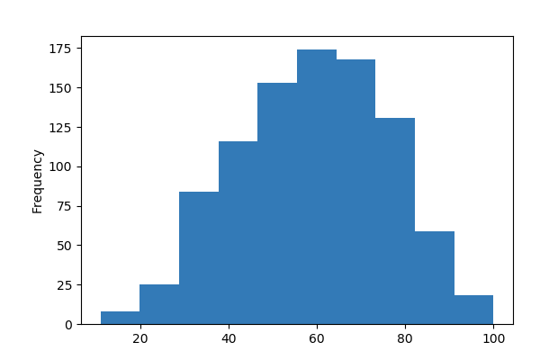

**Common Values**

| Value | Count | Frequency (%) |  |
| --- | --- | --- | --- |
| 66.0 | 25 | 2.5% |  |
| 72.0 | 25 | 2.5% |  |
| 68.0 | 25 | 2.5% |  |
| 64.0 | 24 | 2.4% |  |
| 57.0 | 23 | 2.3% |  |
| 51.0 | 22 | 2.2% |  |
| 65.0 | 22 | 2.2% |  |
| 48.0 | 21 | 2.1% |  |
| 81.0 | 21 | 2.1% |  |
| 76.0 | 21 | 2.1% |  |
| Other values (74) | 707 | 70.7% |  |
| (Missing) | 64 | 6.4% |  |

**Extreme Values**

Minimum 5 values

| Value | Count | Frequency (%) |  |
| --- | --- | --- | --- |
| 11.0 | 1 | 0.1% |  |
| 15.0 | 1 | 0.1% |  |
| 16.0 | 1 | 0.1% |  |
| 18.0 | 4 | 0.4% |  |
| 19.0 | 1 | 0.1% |  |

Maximum 5 values

| Value | Count | Frequency (%) |  |
| --- | --- | --- | --- |
| 95.0 | 3 | 0.3% |  |
| 96.0 | 4 | 0.4% |  |
| 98.0 | 1 | 0.1% |  |
| 99.0 | 1 | 0.1% |  |
| 100.0 | 1 | 0.1% |  |

Rank  
Numeric

| Distinct count | 1000 |
| --- | --- |
| Unique (%) | 100.0% |
| Missing (%) | 0.0% |
| Missing (n) | 0 |
| Infinite (%) | 0.0% |
| Infinite (n) | 0 |

| Mean | 500.5 |
| --- | --- |
| Minimum | 1 |
| Maximum | 1000 |
| Zeros (%) | 0.0% |

Toggle details

**Statistics**

Quantile statistics

| Minimum | 1 |
| --- | --- |
| 5-th percentile | 50.95 |
| Q1 | 250.75 |
| Median | 500.5 |
| Q3 | 750.25 |
| 95-th percentile | 950.05 |
| Maximum | 1000 |
| Range | 999 |
| Interquartile range | 499.5 |

Descriptive statistics

| Standard deviation | 288.82 |
| --- | --- |
| Coef of variation | 0.57706 |
| Kurtosis | -1.2 |
| Mean | 500.5 |
| MAD | 250 |
| Skewness | 0 |
| Sum | 500500 |
| Variance | 83417 |
| Memory size | 7.9 KiB |

**Histogram**

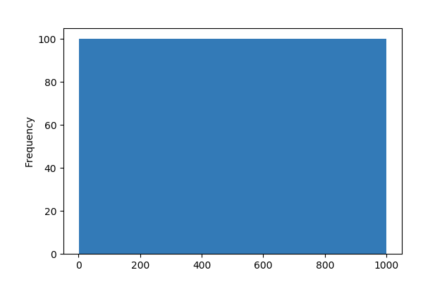

**Common Values**

| Value | Count | Frequency (%) |  |
| --- | --- | --- | --- |
| 1000 | 1 | 0.1% |  |
| 329 | 1 | 0.1% |  |
| 342 | 1 | 0.1% |  |
| 341 | 1 | 0.1% |  |
| 340 | 1 | 0.1% |  |
| 339 | 1 | 0.1% |  |
| 338 | 1 | 0.1% |  |
| 337 | 1 | 0.1% |  |
| 336 | 1 | 0.1% |  |
| 335 | 1 | 0.1% |  |
| Other values (990) | 990 | 99.0% |  |

**Extreme Values**

Minimum 5 values

| Value | Count | Frequency (%) |  |
| --- | --- | --- | --- |
| 1 | 1 | 0.1% |  |
| 2 | 1 | 0.1% |  |
| 3 | 1 | 0.1% |  |
| 4 | 1 | 0.1% |  |
| 5 | 1 | 0.1% |  |

Maximum 5 values

| Value | Count | Frequency (%) |  |
| --- | --- | --- | --- |
| 996 | 1 | 0.1% |  |
| 997 | 1 | 0.1% |  |
| 998 | 1 | 0.1% |  |
| 999 | 1 | 0.1% |  |
| 1000 | 1 | 0.1% |  |

Rating  
Numeric

| Distinct count | 55 |
| --- | --- |
| Unique (%) | 5.5% |
| Missing (%) | 0.0% |
| Missing (n) | 0 |
| Infinite (%) | 0.0% |
| Infinite (n) | 0 |

| Mean | 6.7232 |
| --- | --- |
| Minimum | 1.9 |
| Maximum | 9 |
| Zeros (%) | 0.0% |

Toggle details

**Statistics**

Quantile statistics

| Minimum | 1.9 |
| --- | --- |
| 5-th percentile | 5.1 |
| Q1 | 6.2 |
| Median | 6.8 |
| Q3 | 7.4 |
| 95-th percentile | 8.1 |
| Maximum | 9 |
| Range | 7.1 |
| Interquartile range | 1.2 |

Descriptive statistics

| Standard deviation | 0.94543 |
| --- | --- |
| Coef of variation | 0.14062 |
| Kurtosis | 1.3223 |
| Mean | 6.7232 |
| MAD | 0.7398 |
| Skewness | -0.74314 |
| Sum | 6723.2 |
| Variance | 0.89384 |
| Memory size | 7.9 KiB |

**Histogram**

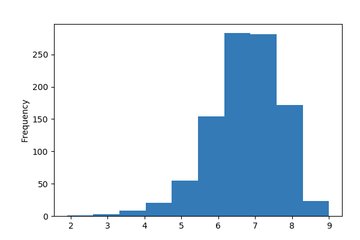

**Common Values**

| Value | Count | Frequency (%) |  |
| --- | --- | --- | --- |
| 7.1 | 52 | 5.2% |  |
| 6.7 | 48 | 4.8% |  |
| 7.0 | 46 | 4.6% |  |
| 6.3 | 44 | 4.4% |  |
| 6.6 | 42 | 4.2% |  |
| 7.2 | 42 | 4.2% |  |
| 7.3 | 42 | 4.2% |  |
| 6.5 | 40 | 4.0% |  |
| 7.8 | 40 | 4.0% |  |
| 6.2 | 37 | 3.7% |  |
| Other values (45) | 567 | 56.7% |  |

**Extreme Values**

Minimum 5 values

| Value | Count | Frequency (%) |  |
| --- | --- | --- | --- |
| 1.9 | 1 | 0.1% |  |
| 2.7 | 2 | 0.2% |  |
| 3.2 | 1 | 0.1% |  |
| 3.5 | 2 | 0.2% |  |
| 3.7 | 2 | 0.2% |  |

Maximum 5 values

| Value | Count | Frequency (%) |  |
| --- | --- | --- | --- |
| 8.4 | 4 | 0.4% |  |
| 8.5 | 6 | 0.6% |  |
| 8.6 | 3 | 0.3% |  |
| 8.8 | 2 | 0.2% |  |
| 9.0 | 1 | 0.1% |  |

Revenue (Millions)  
Numeric

| Distinct count | 815 |
| --- | --- |
| Unique (%) | 81.5% |
| Missing (%) | 12.8% |
| Missing (n) | 128 |
| Infinite (%) | 0.0% |
| Infinite (n) | 0 |

| Mean | 82.956 |
| --- | --- |
| Minimum | 0 |
| Maximum | 936.63 |
| Zeros (%) | 0.1% |

Toggle details

**Statistics**

Quantile statistics

| Minimum | 0 |
| --- | --- |
| 5-th percentile | 0.211 |
| Q1 | 13.27 |
| Median | 47.985 |
| Q3 | 113.72 |
| 95-th percentile | 293.88 |
| Maximum | 936.63 |
| Range | 936.63 |
| Interquartile range | 100.45 |

Descriptive statistics

| Standard deviation | 103.25 |
| --- | --- |
| Coef of variation | 1.2447 |
| Kurtosis | 10.608 |
| Mean | 82.956 |
| MAD | 72.372 |
| Skewness | 2.5925 |
| Sum | 72338 |
| Variance | 10661 |
| Memory size | 7.9 KiB |

**Histogram**

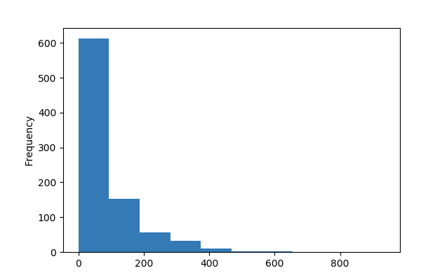

**Common Values**

| Value | Count | Frequency (%) |  |
| --- | --- | --- | --- |
| 0.03 | 7 | 0.7% |  |
| 0.01 | 5 | 0.5% |  |
| 0.04 | 4 | 0.4% |  |
| 0.02 | 4 | 0.4% |  |
| 0.32 | 4 | 0.4% |  |
| 0.05 | 4 | 0.4% |  |
| 1.29 | 3 | 0.3% |  |
| 0.15 | 3 | 0.3% |  |
| 2.2 | 3 | 0.3% |  |
| 0.54 | 3 | 0.3% |  |
| Other values (804) | 832 | 83.2% |  |
| (Missing) | 128 | 12.8% |  |

**Extreme Values**

Minimum 5 values

| Value | Count | Frequency (%) |  |
| --- | --- | --- | --- |
| 0.0 | 1 | 0.1% |  |
| 0.01 | 5 | 0.5% |  |
| 0.02 | 4 | 0.4% |  |
| 0.03 | 7 | 0.7% |  |
| 0.04 | 4 | 0.4% |  |

Maximum 5 values

| Value | Count | Frequency (%) |  |
| --- | --- | --- | --- |
| 533.32 | 1 | 0.1% |  |
| 623.28 | 1 | 0.1% |  |
| 652.18 | 1 | 0.1% |  |
| 760.51 | 1 | 0.1% |  |
| 936.63 | 1 | 0.1% |  |

Runtime (Minutes)  
Numeric

| Distinct count | 94 |
| --- | --- |
| Unique (%) | 9.4% |
| Missing (%) | 0.0% |
| Missing (n) | 0 |
| Infinite (%) | 0.0% |
| Infinite (n) | 0 |

| Mean | 113.17 |
| --- | --- |
| Minimum | 66 |
| Maximum | 191 |
| Zeros (%) | 0.0% |

Toggle details

**Statistics**

Quantile statistics

| Minimum | 66 |
| --- | --- |
| 5-th percentile | 88 |
| Q1 | 100 |
| Median | 111 |
| Q3 | 123 |
| 95-th percentile | 150 |
| Maximum | 191 |
| Range | 125 |
| Interquartile range | 23 |

Descriptive statistics

| Standard deviation | 18.811 |
| --- | --- |
| Coef of variation | 0.16622 |
| Kurtosis | 0.85832 |
| Mean | 113.17 |
| MAD | 14.669 |
| Skewness | 0.84671 |
| Sum | 113172 |
| Variance | 353.85 |
| Memory size | 7.9 KiB |

**Histogram**

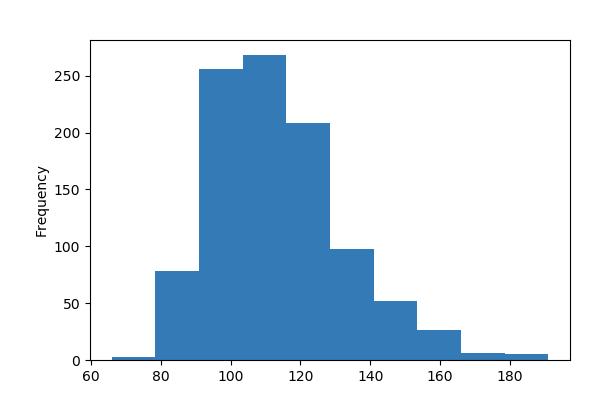

**Common Values**

| Value | Count | Frequency (%) |  |
| --- | --- | --- | --- |
| 108 | 31 | 3.1% |  |
| 100 | 28 | 2.8% |  |
| 117 | 27 | 2.7% |  |
| 110 | 26 | 2.6% |  |
| 106 | 26 | 2.6% |  |
| 118 | 26 | 2.6% |  |
| 102 | 25 | 2.5% |  |
| 112 | 24 | 2.4% |  |
| 104 | 23 | 2.3% |  |
| 123 | 23 | 2.3% |  |
| Other values (84) | 741 | 74.1% |  |

**Extreme Values**

Minimum 5 values

| Value | Count | Frequency (%) |  |
| --- | --- | --- | --- |
| 66 | 1 | 0.1% |  |
| 73 | 2 | 0.2% |  |
| 80 | 2 | 0.2% |  |
| 81 | 5 | 0.5% |  |
| 82 | 1 | 0.1% |  |

Maximum 5 values

| Value | Count | Frequency (%) |  |
| --- | --- | --- | --- |
| 170 | 1 | 0.1% |  |
| 172 | 1 | 0.1% |  |
| 180 | 3 | 0.3% |  |
| 187 | 1 | 0.1% |  |
| 191 | 1 | 0.1% |  |

Title  
Categorical

| Distinct count | 999 |
| --- | --- |
| Unique (%) | 99.9% |
| Missing (%) | 0.0% |
| Missing (n) | 0 |

| The Host | 2 |
| --- | --- |
| Paint It Black | 1 |
| Captain America: Civil War | 1 |
| Other values (996) | 996 |

Toggle details

| Value | Count | Frequency (%) |  |
| --- | --- | --- | --- |
| The Host | 2 | 0.2% |  |
| Paint It Black | 1 | 0.1% |  |
| Captain America: Civil War | 1 | 0.1% |  |
| Deja Vu | 1 | 0.1% |  |
| In Bruges | 1 | 0.1% |  |
| Ben-Hur | 1 | 0.1% |  |
| I Am the Pretty Thing That Lives in the House | 1 | 0.1% |  |
| Hugo | 1 | 0.1% |  |
| Spring Breakers | 1 | 0.1% |  |
| Rocky Balboa | 1 | 0.1% |  |
| Other values (989) | 989 | 98.9% |  |

Votes  
Numeric

| Distinct count | 997 |
| --- | --- |
| Unique (%) | 99.7% |
| Missing (%) | 0.0% |
| Missing (n) | 0 |
| Infinite (%) | 0.0% |
| Infinite (n) | 0 |

| Mean | 169810 |
| --- | --- |
| Minimum | 61 |
| Maximum | 1791916 |
| Zeros (%) | 0.0% |

Toggle details

**Statistics**

Quantile statistics

| Minimum | 61 |
| --- | --- |
| 5-th percentile | 1260.4 |
| Q1 | 36309 |
| Median | 110800 |
| Q3 | 239910 |
| 95-th percentile | 526550 |
| Maximum | 1791916 |
| Range | 1791855 |
| Interquartile range | 203600 |

Descriptive statistics

| Standard deviation | 188760 |
| --- | --- |
| Coef of variation | 1.1116 |
| Kurtosis | 11.313 |
| Mean | 169810 |
| MAD | 135480 |
| Skewness | 2.5079 |
| Sum | 169808255 |
| Variance | 35631000000 |
| Memory size | 7.9 KiB |

**Histogram**

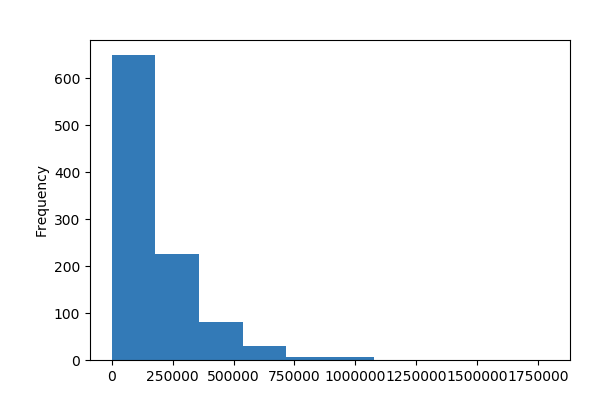

**Common Values**

| Value | Count | Frequency (%) |  |
| --- | --- | --- | --- |
| 1427 | 2 | 0.2% |  |
| 97141 | 2 | 0.2% |  |
| 291 | 2 | 0.2% |  |
| 531112 | 1 | 0.1% |  |
| 702 | 1 | 0.1% |  |
| 47804 | 1 | 0.1% |  |
| 226619 | 1 | 0.1% |  |
| 76469 | 1 | 0.1% |  |
| 125693 | 1 | 0.1% |  |
| 174553 | 1 | 0.1% |  |
| Other values (987) | 987 | 98.7% |  |

**Extreme Values**

Minimum 5 values

| Value | Count | Frequency (%) |  |
| --- | --- | --- | --- |
| 61 | 1 | 0.1% |  |
| 96 | 1 | 0.1% |  |
| 102 | 1 | 0.1% |  |
| 115 | 1 | 0.1% |  |
| 164 | 1 | 0.1% |  |

Maximum 5 values

| Value | Count | Frequency (%) |  |
| --- | --- | --- | --- |
| 1045588 | 1 | 0.1% |  |
| 1047747 | 1 | 0.1% |  |
| 1222645 | 1 | 0.1% |  |
| 1583625 | 1 | 0.1% |  |
| 1791916 | 1 | 0.1% |  |

Year  
Numeric

| Distinct count | 11 |
| --- | --- |
| Unique (%) | 1.1% |
| Missing (%) | 0.0% |
| Missing (n) | 0 |
| Infinite (%) | 0.0% |
| Infinite (n) | 0 |

| Mean | 2012.8 |
| --- | --- |
| Minimum | 2006 |
| Maximum | 2016 |
| Zeros (%) | 0.0% |

Toggle details

**Statistics**

Quantile statistics

| Minimum | 2006 |
| --- | --- |
| 5-th percentile | 2007 |
| Q1 | 2010 |
| Median | 2014 |
| Q3 | 2016 |
| 95-th percentile | 2016 |
| Maximum | 2016 |
| Range | 10 |
| Interquartile range | 6 |

Descriptive statistics

| Standard deviation | 3.206 |
| --- | --- |
| Coef of variation | 0.0015928 |
| Kurtosis | -0.82196 |
| Mean | 2012.8 |
| MAD | 2.752 |
| Skewness | -0.68988 |
| Sum | 2012783 |
| Variance | 10.278 |
| Memory size | 7.9 KiB |

**Histogram**

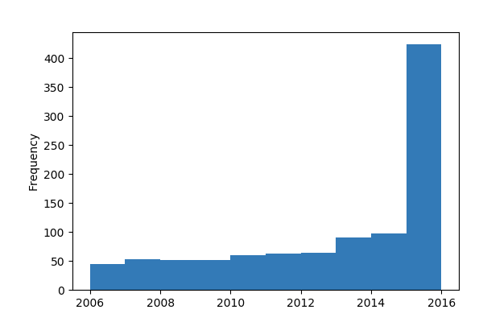

**Common Values**

| Value | Count | Frequency (%) |  |
| --- | --- | --- | --- |
| 2016 | 297 | 29.7% |  |
| 2015 | 127 | 12.7% |  |
| 2014 | 98 | 9.8% |  |
| 2013 | 91 | 9.1% |  |
| 2012 | 64 | 6.4% |  |
| 2011 | 63 | 6.3% |  |
| 2010 | 60 | 6.0% |  |
| 2007 | 53 | 5.3% |  |
| 2008 | 52 | 5.2% |  |
| 2009 | 51 | 5.1% |  |

**Extreme Values**

Minimum 5 values

| Value | Count | Frequency (%) |  |
| --- | --- | --- | --- |
| 2006 | 44 | 4.4% |  |
| 2007 | 53 | 5.3% |  |
| 2008 | 52 | 5.2% |  |
| 2009 | 51 | 5.1% |  |
| 2010 | 60 | 6.0% |  |

Maximum 5 values

| Value | Count | Frequency (%) |  |
| --- | --- | --- | --- |
| 2012 | 64 | 6.4% |  |
| 2013 | 91 | 9.1% |  |
| 2014 | 98 | 9.8% |  |
| 2015 | 127 | 12.7% |  |
| 2016 | 297 | 29.7% |  |

# Correlations

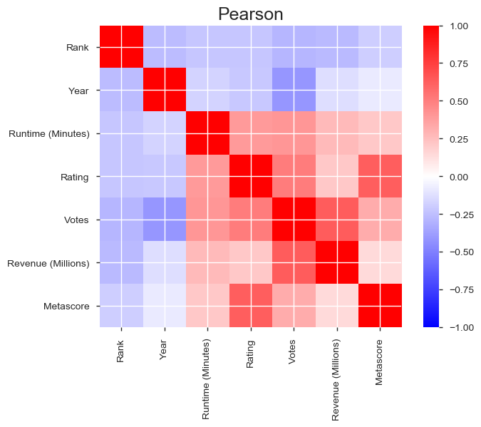

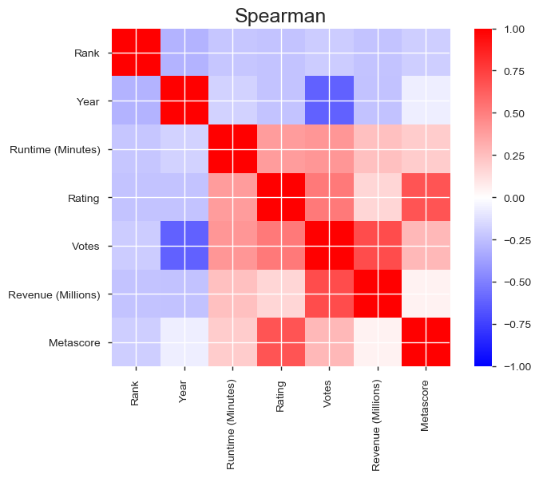

# Sample

|  | Rank | Title | Genre | Description | Director | Actors | Year | Runtime (Minutes) | Rating | Votes | Revenue (Millions) | Metascore |
| --- | --- | --- | --- | --- | --- | --- | --- | --- | --- | --- | --- | --- |
| 0 | 1 | Guardians of the Galaxy | Action,Adventure,Sci-Fi | A group of intergalactic criminals are forced ... | James Gunn | Chris Pratt, Vin Diesel, Bradley Cooper, Zoe S... | 2014 | 121 | 8.1 | 757074 | 333.13 | 76.0 |
| 1 | 2 | Prometheus | Adventure,Mystery,Sci-Fi | Following clues to the origin of mankind, a te... | Ridley Scott | Noomi Rapace, Logan Marshall-Green, Michael Fa... | 2012 | 124 | 7.0 | 485820 | 126.46 | 65.0 |
| 2 | 3 | Split | Horror,Thriller | Three girls are kidnapped by a man with a diag... | M. Night Shyamalan | James McAvoy, Anya Taylor-Joy, Haley Lu Richar... | 2016 | 117 | 7.3 | 157606 | 138.12 | 62.0 |
| 3 | 4 | Sing | Animation,Comedy,Family | In a city of humanoid animals, a hustling thea... | Christophe Lourdelet | Matthew McConaughey,Reese Witherspoon, Seth Ma... | 2016 | 108 | 7.2 | 60545 | 270.32 | 59.0 |
| 4 | 5 | Suicide Squad | Action,Adventure,Fantasy | A secret government agency recruits some of th... | David Ayer | Will Smith, Jared Leto, Margot Robbie, Viola D... | 2016 | 123 | 6.2 | 393727 | 325.02 | 40.0 |